# Hanging in there: the highs and lows of a flying-fox camp in a novel landscape

Wilson B A & Rapley S

March 01, 2026

# 1 **Background**

This [R project](https://support.posit.co/hc/en-us/articles/200526207-Using-RStudio-Projects) presents the datasets and workflows used in the ‘[ABS Commonwealth Park flying-fox monitoring program](https://sites.google.com/view/absflyingfoxmonitoringact/) publication *Hanging in there: the highs and lows of a flying-fox camp in a novel landscape*’. For information, visit the [GitHub repo](https://github.com/ecologibel/commonwealth-park-flying-fox-monitoring).

# 2 **Setup**

## 2.1 Install and load packages

1. Dependancies

The `ccl` package provides lab-specific functions used throughout this template, and `pacman` lets you install and load multiple packages at once.

> Run this chunk once when setting up a new project.

```r
# Install ccl package from GitHub (run once; skip if already installed)
remotes::install_github("coexistence-conservation-lab/ccl")
```

> Run this chunk every time you load the project.

```r
# Update ccl package if a newer version is available
remotes::update_packages("ccl")

# Load ccl package
library(ccl)

# Load pacman (manages package installation and loading in one step)
library(pacman)
```

2. Project-specific packages

```r
# Install and load packages
pacman::p_load(

  # Data import and export
  openxlsx, readxl, writexl, yaml,

  # Data wrangling
  broom, ggh4x, grid, hms, janitor, tidyverse, naniar, reshape2,

  # Mapping
  ggmap, sf,

  # Plotting
  corrplot, ggpubr, scales, viridis, viridisLite,

  # Reporting
  english, kableExtra, rlang, rprojroot,

  # Statistical modelling
  lme4, MuMIn,

  # Utilities
  beepr, cli, crayon, glue, here

)

# Prevent other packages (e.g., cowplot) from masking dplyr functions
select <- dplyr::select
recode <- dplyr::recode
```

## 2.2 Define resources

### 2.2.1 Abbreviations

Prints a formatted table of abbreviations and key terms.

```r
# Read in abbrevations list and print it as a clean table
(def <- print_clean_table(raw_data, sheet = "definitions"))
```

| Abbreviation | Definition | Description, units, or values |
| --- | --- | --- |
| ABS | [Australasian Bat Society](https://www.ausbats.org.au/) |  |
| ACT | Australian Capital Territory |  |
| API | Application Programming Interface |  |
| BOM | [The Bureau of Meteorology](https://www.bom.gov.au/) |  |
| `can` | Canopy cover | % |
| CSIRO | [Commonwealth Scientific and Industrial Research Organisation](https://www.csiro.au/en/) |  |
| `df` | Dataframe |  |
| `ds` | Dynamic summary |  |
| `euca` | Eucalypt trees |  |
| FF | [Flying-fox](https://australian.museum/learn/animals/bats/) | *Pteropus* spp. |
| GHFF | [Grey-headed flying-fox](https://australian.museum/learn/animals/bats/grey-headed-flying-fox/) | *Pteropus poliocephalus* |
| `id` | Identity |  |
| `lat` | Latitude |  |
| `laur` | Laurel trees |  |
| `lcl` | Lower confidence level |  |
| `lon` | Longitude |  |
| LRFF | [Little red flying-fox](https://australian.museum/learn/animals/bats/little-red-flying-fox/) | *Pteropus scapulatus* |
| `n` | Number | *n* |
| NCA | [National Capital Authority](https://www.nca.gov.au/) |  |
| NFFMP | [National Flying-fox Monitoring Program](https://www.dcceew.gov.au/environment/biodiversity/threatened/species/flying-fox-monitoring) |  |
| `oaks` | Oak or broadleafed trees |  |
| `perc` | Percentage | % |
| `pine` | Pine or needleleaf trees |  |
| `spp` | Species |  |
| `tab` | Table |  |
| `tot` | Total |  |
| `var` | Variable |  |

## 2.3 Authorisations

```r
# Check and register Google Maps API key in metadata folder
check_google_maps_api_key()
```

```
## ✔ Google Maps API key registered successfully
```

### 2.3.1 Set constants

Defines constant values.

#### 2.3.1.1 Project

```r
# Define dates for current reporting period
REP_START     <- "2024-12-01"
REP_END       <- "2025-11-30"
REP_YEAR          <- 2025

# Define dates for tree-by-tree surveys
TREE_START    <- as.Date("2018-12-15")
TREE_END      <- as.Date("2024-09-29")

# Define dates for all surveys
ALL_START     <- as.Date("2012-01-01")
ALL_END       <- REP_END

# Define whether LRFFs were recorded in the last reporting period
LRFFS_PRESENT <- FALSE

# Define visual scaling factor to align trees occupied with FF abundance
TREE_SCALE    <- 20

# Define visual scaling factor to align FF abundance with temperature
FF_SCALE      <- 200

# Define visual scaling factors for ENSO Niño3.4 values
ENSO_NEU     <- 0.8
ENSO_ADJ      <- 4000
```

#### 2.3.1.2 Maps

```r
# Define constant ggplot arguments
map_height  <- 6
map_width   <- 6
plot_height <- 6
plot_width  <- 9
dpi         <- 300
```

#### 2.3.1.3 Levels

```r
# Define columns in `monitoring` sheet
monitoring_cols <- c(
  "location",
  "survey",
  "date",
  "start",
  "finish",
  "hours",
  "ghff",
  "lrff",
  "trees_occupied",
  "mothers_and_pups",
  "heat_stress",
  "wind",
  "cloud",
  "humidity",
  "bat_noise",
  "other_noise",
  "rubbish",
  "humans",
  "include")

# Define categorical variables
cat_vars <- c(
  "pups",
  "heat",
  "bat_noise",
  "other_noise",
  "humans",
  "rubbish",
  "cloud",
  "humid",
  "wind")

# Define long labels for categorical variables
cat_labs <- c(
  "pups"        = "Presence of mothers and pups",
  "heat"        = "Heat stress behaviours",
  "bat_noise"   = "Flying-fox noise",
  "other_noise" = "Other noise",
  "humans"      = "Presence of humans",
  "rubbish"     = "Presence of litter",
  "cloud"       = "Cloud cover",
  "humid"       = "In situ humidity",
  "wind"        = "Wind strength")
```

#### 2.3.1.4 Colours

```r
# Define and load project-specific colours as objects
quiet(list2env(
  list(
    powder = "#CACBE8",
    lilac  = "#6B6FD6",
    purple = "#1F2148",
    pine   = "#2F5D50",
    green  = "#458B00",
    lime   = "#A1CC76",
    olive  = "#7A8F5B",
    tan    = "#C4A487",
    brown  = "#8B6B4F",
    orange = "#D36C2A"),
  envir    = globalenv()))
```

```
## <environment: R_GlobalEnv>
```

### 2.3.2 Build functions

```r
# Define function to convert Excel times to hms
to_hms <- function(x) {
  # Leave hms values unchanged
  if (inherits(x, "hms")) {
    return(x)}

  # Extract time-of-day from POSIXct/POSIXlt datetimes
  if (inherits(x, "POSIXt")) {
    return(hms::as_hms(as.numeric(x) %% 86400))}

  # Convert difftime durations to seconds
  if (inherits(x, "difftime")) {
    return(hms::as_hms(as.numeric(x, units = "secs")))}

  # Handle numeric Excel times by keeping the fractional day
  if (is.numeric(x)) {
    frac_day <- x %% 1
    return(hms::as_hms(frac_day * 86400))}

  # Parse character times and treat blanks as missing
  x_chr <- na_if(trimws(as.character(x)), "")
  hms::as_hms(readr::parse_time(x_chr, format = "%H:%M"))}
```

# 3 **Preparation**

We entered the FF survey data in a [Microsoft Access](https://www.microsoft.com/en-au/microsoft-365/access) database. To put this into a form that we can use in this R markdown:

1. Copy the `Survey` and `Tree` tables from the database into their respective sheets in `input/raw data.xlsx`.
2. Copy the rows from the last reporting period (Dec 1–Nov 30) in the `Schedule` sheet of the `ABS flying-fox monitoring` Google spreadsheet (requires specific access) to the bottom of the `monitoring` sheet.

```r
# Read in data
dat <- read_excel(raw_data, sheet = "monitoring") %>%

  # Standardise column names
  clean_names() %>%

  # Select relevant columns
  select(all_of(monitoring_cols)) %>%

  # Convert columns
  mutate(
    # Convert dates and times
    across(c(start, finish, hours), to_hms),
    ghff = as.character(ghff),
    lrff = as.character(lrff)) %>%

  # Filter to relevant site
  filter(
    include  == "Yes",
    location == "Commonwealth Park")
```

# 4 **Sections**

## 4.1 Abundance and trees occupied

First, we generate a **(a)** raw line graph and a **(b)** smoothed line graph by month, with two y-axes:

```r
# Pivot df to long format
dat_wide <- dat %>%

  pivot_longer(
    cols      = c("ghff", "lrff"),
    names_to  = "species",
    values_to = "count") %>%

  # Convert count values
  mutate(count = if_else(count == "800-1000", "900", count)) %>%
  mutate(count = if_else(count == "200-250",  "225", count)) %>%

  # Replace ranges with mean
  mutate(
    count          = as.numeric(count),
    trees_occupied = as.numeric(trees_occupied),
    date           = as.Date(date, format = c("%d/%m/%Y"))) %>%
  mutate(year      = year(date))

# Subset to current reporting period
dat_cur <- dat_wide %>%
  filter(date > REP_START & date < REP_END) %>%

  # Include LRFFs if LRFFS_PRESENT = TRUE
  filter(LRFFS_PRESENT | species != "lrff")

# Export df to a new sheet in the running workbook
workbook <- export_sheet(dat_cur, sheet = "data")
```

### 4.1.1 Raw line graph

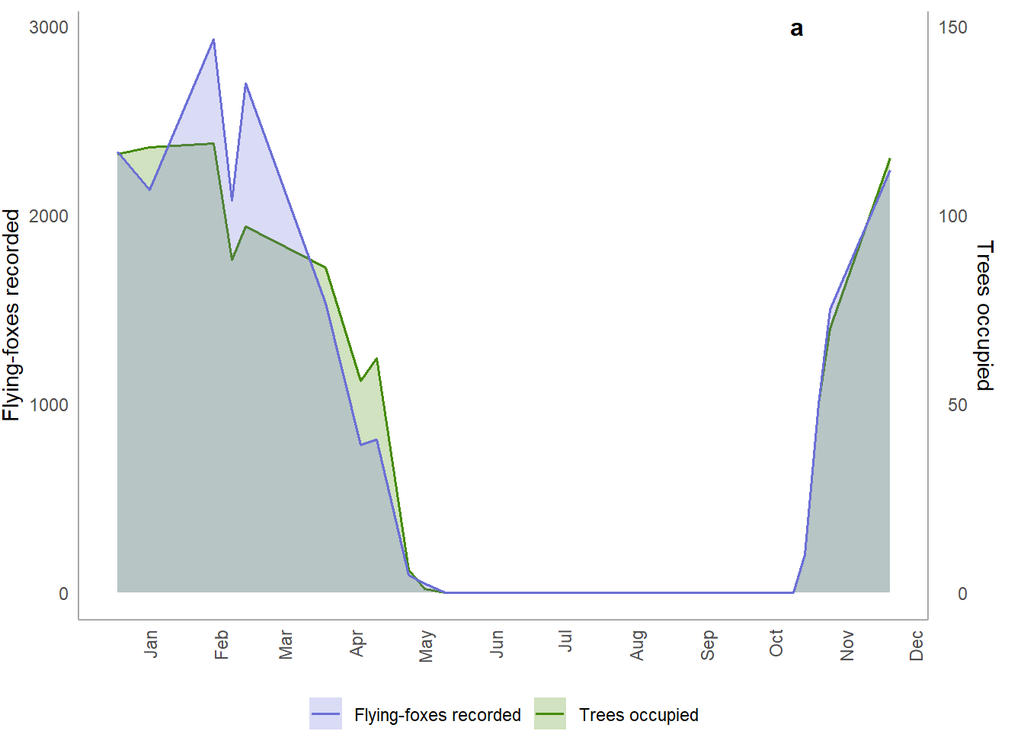

```r
# Line plot raw abundance
(abun_line <- ggplot(dat_cur) +

  geom_ribbon(
    aes(
      fill = "Trees occupied",
      x    = date,
      ymin = 0,
      ymax = trees_occupied * TREE_SCALE),
    alpha  = 0.25,
    colour = NA,
    na.rm  = TRUE) +

  geom_line(
    mapping   = aes(
      col     = "Trees occupied",
      x       = date,
      y       = trees_occupied * TREE_SCALE),
    linewidth = 0.7) +

  geom_ribbon(
    aes(
      fill = "Flying-foxes recorded",
      x    = date,
      ymin = 0,
      ymax = count),       ,
    alpha  = 0.25,
    colour = NA) +

  geom_line(
    mapping   = aes(
      col     = "Flying-foxes recorded",
      x       = date,
      y       = count),
    linewidth = 0.7) +

  labs(
    tag = "a",
    x   = "Month",
    y   = "Flying-foxes recorded") +

  scale_color_manual(
  name   = "",
  values = c(
    "Trees occupied"        = green,
    "Flying-foxes recorded" = lilac)) +

  scale_fill_manual(
  name   = "",
  values = c(
    "Trees occupied"        = green,
    "Flying-foxes recorded" = lilac)) +

  scale_x_date(
    date_breaks = "1 month",
    date_labels = "%b") +

  scale_y_continuous(
    sec.axis = sec_axis(~ ./TREE_SCALE, name = "Trees occupied")) +

  theme_minimal() +
  theme(
    axis.line         = element_line(colour = mono3),
    axis.text.x       = element_text(angle = 90, hjust = 1, vjust = 1),
    axis.text.y       = element_text(vjust = 0.5),
    axis.title.x      = element_blank(),
    axis.title.y      = element_text(vjust = 2, margin = margin(r = 1)),
    legend.position   = "bottom",
    legend.title      = element_blank(),
    panel.background  = element_rect(fill = "white", colour = NA),
    panel.grid        = element_blank(),
    plot.margin       = margin(t = 0.2, r = 0.5, b = -0.2, l = 0.1, "cm"),
    plot.tag          = element_text(face = "bold", size = 12),
    plot.tag.position = c(0.8, 0.98)))
```

### 4.1.2 Smoothed line graph

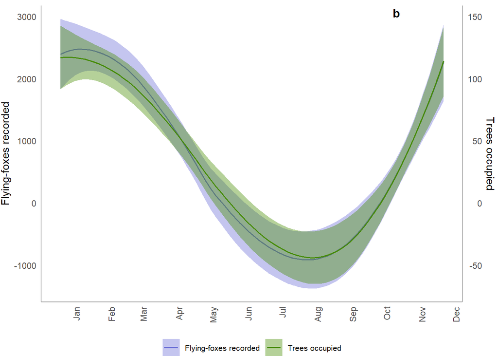

```r
# Smooth plot abundance
(abun_smooth <- ggplot(dat_cur) +

  geom_smooth(
    mapping   = aes(
      col     = "Flying-foxes recorded",
      fill    = "Flying-foxes recorded",
      x       = date,
      y       = count),
    linewidth = 0.7) +

  geom_smooth(
    mapping   = aes(
      col     = "Trees occupied",
      fill    = "Trees occupied",
      x       =  date,
      y       =  trees_occupied * TREE_SCALE),
    linewidth = 0.7,
    na.rm     = TRUE) +

  labs(
    tag = "b",
    x   = "Month",
    y   = "Flying-foxes recorded") +

  scale_color_manual(
  name   = "",
  values = c(
    "Trees occupied"        = green,
    "Flying-foxes recorded" = lilac)) +

  scale_fill_manual(
  name   = "",
  values = c(
    "Trees occupied"        = green,
    "Flying-foxes recorded" = lilac)) +

  scale_x_date(
    date_breaks = "1 month",
    date_labels = "%b") +

  scale_y_continuous(
    sec.axis    = sec_axis(~ ./TREE_SCALE, name = "Trees occupied")) +

  theme_minimal() +
  theme(
    axis.line         = element_line(colour = mono3),
    axis.text.x       = element_text(angle = 90, hjust = 1, vjust = 1),
    axis.text.y       = element_text(vjust = 0.5),
    axis.title.x      = element_blank(),
    axis.title.y      = element_text(vjust = 2, margin = margin(r = 1)),
    legend.text       = element_text(size  = 8),
    legend.position   = "bottom",
    legend.title      = element_blank(),
    panel.background  = element_rect(fill = "white", colour = NA),
    panel.border      = element_blank(),
    panel.grid.major  = element_blank(),
    panel.grid.minor  = element_blank(),
    plot.margin       = margin(t = 0.2, r = 0.1, b = -0.2, l = 0.1, "cm"),
    plot.tag          = element_text(face = "bold", size = 12),
    plot.tag.position = c(0.8, 0.98)))
```

## 4.2 Mean abundance per month

### 4.2.1 Import

```r
# Read in the data
dat_cur2 <- dat_cur %>%

  mutate(
    month      = lubridate::month(
      date,
      label    = TRUE,
      abbr     = TRUE),
    count      = as.numeric(count),
    ratio      = as.numeric(count / trees_occupied)) %>%

  mutate(ratio = ifelse(ratio == "NaN", 0, ratio))

# Calculate mean statistics
dat_cur_mean <- dat_cur2 %>%
  group_by(month) %>%

  summarise(
    count_mean = mean(count),
    ratio_mean = TREE_SCALE * mean(ratio),
    trees_mean = TREE_SCALE * mean(trees_occupied)) %>%

  pivot_longer(
    2:4,
    names_to = "type",
    values_to = "mean")

# Calculate standard error (SE) statistics
dat_cur_se <- dat_cur2 %>%
  group_by(month) %>%

  summarise(
    count_se = sd(count) /
      sqrt(length(count)),

    ratio_se = TREE_SCALE * sd(ratio) /
      sqrt(length(ratio)),

    trees_se = TREE_SCALE * sd(trees_occupied) /
      sqrt(length(trees_occupied))) %>%

  pivot_longer(
    2:4,
    names_to  = "type",
    values_to = "se")

# Combine means and SE
dat_cur_stats <- cbind(
  dat_cur_mean,
  dat_cur_se)

colnames(dat_cur_stats) <- make.unique(names(dat_cur_stats))
```

For each month, regardless of whether FFs were detected, manually generate rows for these months.

```r
# Manually create rows for months where bats were not detected
jul <- data.frame(
  "Jul",
  "count_mean",
  NA,
  "Jul",
  "count_se",
  NA)

names(jul) <- c(
  "month",
  "type",
  "mean",
  "month.1",
  "type.1",
  "se")

aug <- data.frame(
  "Aug",
  "count_mean",
  NA,
  "Aug",
  "count_se",
  NA)

names(aug) <- c(
  "month",
  "type",
  "mean",
  "month.1",
  "type.1",
  "se")

sep <- data.frame(
  "Sep",
  "count_mean",
  NA,
  "Sep",
  "count_se",
  NA)

names(sep) <- c(
  "month",
  "type",
  "mean",
  "month.1",
  "type.1",
  "se")

# Combine rows with df
dat_current_stats <- rbind(
  dat_cur_stats,
  jul,
  aug,
  sep) %>%

  mutate(
    type = factor(type, levels = c(
      "count_mean",
      "trees_mean",
      "ratio_mean",
      "count_se",
      "trees_se",
      "ratio_se")),

    month = factor(month, levels = c(
      "Dec", "Jan", "Feb",
      "Mar", "Apr", "May",
      "Jun", "Jul", "Aug",
      "Sep", "Oct", "Nov")))

# Reverse × 40 multiplier
dat_cur_stats$true <- dat_cur_stats$mean/TREE_SCALE

# Create a three-level grouping variable for metrics
dat_cur_stats <- dat_cur_stats %>%
  mutate(metric = sub("_(mean|se)$", "", type))
```

### 4.2.2 Plot

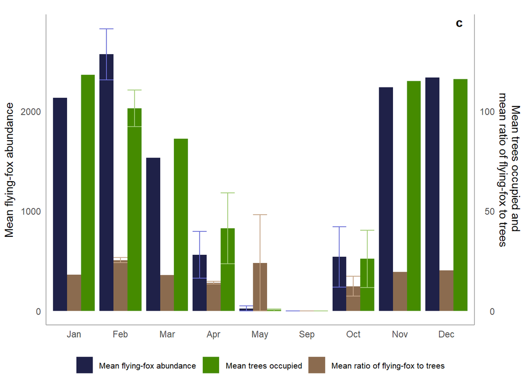

```r
# Generate barplot
(abun_mean <- ggplot(
  dat_cur_stats,
  aes(
    fill = metric,
    x    = month,
    y    = mean)) +

  # Draw barplot
  geom_col(position = "dodge") +

  # Draw errorbars
  geom_errorbar(
    mapping = aes(
      col   = metric,
      x     = month,
      ymax  = mean + se,
      ymin  = mean - se),
    position = "dodge") +

  labs(
    tag = "c",
    x   = "Month",
    y   = "Mean flying-fox abundance") +

  # Configure axes
  scale_colour_manual(
  name    = "",
  breaks  = c("count", "trees", "ratio"),
  guide   = "none",
  labels  = c(
    "Mean flying-fox abundance",
    "Mean trees occupied",
    "Mean ratio of flying-fox to trees"),
  values  = c(
    count = lilac,
    trees = lime,
    ratio = tan)) +

  scale_fill_manual(
  name   = "",
  breaks = c("count", "trees", "ratio"),
  labels = c(
    "Mean flying-fox abundance",
    "Mean trees occupied",
    "Mean ratio of flying-fox to trees"),
  values  = c(
    count = purple,
    trees = green,
    ratio = brown)) +

  scale_y_continuous(
    sec.axis = sec_axis(
      ~ ./TREE_SCALE,
      name = "Mean trees occupied and \nmean ratio of flying-fox to trees")) +

  # Apply visual theme
  theme_minimal() +
  theme(
    axis.line         = element_line(colour = mono3),
    axis.text.x       = element_text(vjust = 1),
    axis.text.y       = element_text(vjust = 0.5),
    axis.title.x      = element_blank(),
    axis.title.y      = element_text(vjust = 3, margin = margin(r = 1)),
    legend.position   = "bottom",
    legend.text       = element_text(size = 8),
    legend.title      = element_blank(),
    panel.background  = element_rect(colour = NA, fill = "white"),
    panel.grid.major  = element_blank(),
    panel.grid.minor  = element_blank(),
    panel.border      = element_blank(),
    plot.margin       = margin(t = 0.5, r = 0.1, b = -0.2, l = 0.3, "cm"),
    plot.tag          = element_text(face = "bold", size = 12),
    plot.tag.position = c(0.88, 0.98)))
```

### 4.2.3 Combine plots

## 4.3 Mean abundance per year

### 4.3.1 Import

```r
# Prepare the data
dat_all <- dat %>%
  drop_na(ghff) %>%

  mutate(ghff = if_else(ghff == "800-1000", "900", ghff)) %>%

  # Replace ranges with mean
  mutate(ghff = if_else(ghff == "200-250",  "225", ghff)) %>%

  mutate(
    ghff = as.numeric(ghff),
    lrff = as.numeric(lrff),
    year = year(date)) %>%

  mutate(bats_total = ghff + lrff) %>%

  # Remove years prior to year 2011
  filter(year >= lubridate::year(as.Date(ALL_START))) %>%

  # Calculate peak abundance
  group_by(year) %>%
  mutate(peak = max(bats_total, na.rm = TRUE)) %>%
  ungroup()
```

### 4.3.2 Plot

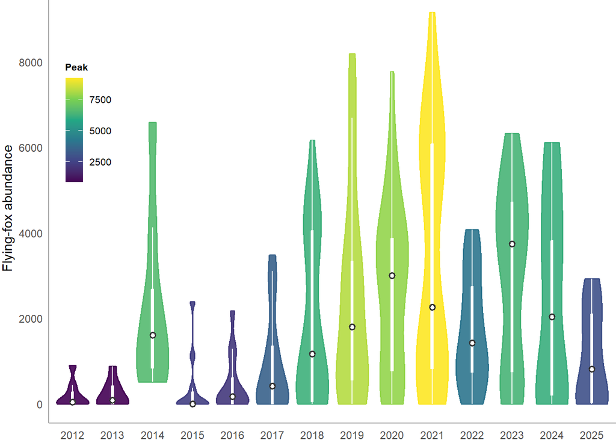

```r
# Bar plot
(abun_year <- ggplot(
  dat_all,
  aes(
    x = factor(year),
    y = bats_total)) +

  # Draw violin plot
  geom_violin(
    aes(col  = peak,
        fill = peak),
    alpha    = 0.9,
    lwd      = 0.6,
    na.rm    = TRUE,
    scale    = "width",
    width    = 0.8) +

  # Draw boxplot
  geom_boxplot(
    col           = "white",
    fill          = "white",
    lwd           = 0.5,
    na.rm         = TRUE,
    outlier.shape = NA,
    width         = 0.05) +

  # Remove white ticks on legend scale
  guides(fill = guide_colorbar(ticks.colour = NA)) +

  # Configure axis titles
  labs(
    x = "Year",
    y = "Flying-fox abundance") +

  # Configure axes
  scale_colour_viridis_c(
    guide          = guide_colorbar(
      barheight    = unit(3, "cm"),
      barwidth     = unit(0.5, "cm")),
    name           = "Peak") +

  scale_fill_viridis_c(
    guide          = guide_colorbar(
      barheight    = unit(3, "cm"),
      barwidth     = unit(0.5, "cm")),
    name           = "Peak") +

  scale_x_discrete(
    drop = FALSE,
    breaks = seq(2011, REP_YEAR, 1)) +

  scale_y_continuous(breaks = seq(0, 10000, 2000)) +

  # Define median value point for boxplot
  stat_summary(
    col    = mono4,
    fill   = "white",
    fun    = "median",
    geom   = "point",
    shape  = 21,
    size   = 1.7,
    stroke = 1) +

  # Apply visual theme
  theme_minimal() +
  theme(
    axis.line        = element_line(colour = mono3),
    axis.text.x      = element_text(vjust  = 0.5),
    axis.title.x     = element_blank(),
    axis.title.y     = element_text(margin = margin(r = 5), vjust = 0.5),
    legend.position  = c(0.07, 0.7),
    legend.text      = element_text(size = 8),
    legend.title     = element_text(face = "bold", size = 8),
    panel.background = element_rect(fill = "white", colour = NA),
    panel.border     = element_blank(),
    panel.grid.major = element_blank(),
    panel.grid.minor = element_blank(),
    plot.margin      = margin(t = -0.2, r = 0, b = 0, l = 0, "cm")))
```

## 4.4 Abundance by weather

Here we overlay a line graph of FF abundance since 2012 with:

1. [BOM maximum and minimum temperatures](http://www.bom.gov.au/climate/data/index.shtml?bookmark%20=%20136)  
   - Navigate to `ACT` > `Past weather` > `Data and graphs` > `Text search` > `Temperature` > `Maximum temperature` or `Minimum temperature` > weather station `70351`
2. [BOM ENSO relative Niño3.4 index](https://www.bom.gov.au/climate/enso/indices.shtml)

### 4.4.1 Import

```r
# Read in weather data
weather <- read_excel(raw_data, sheet = "weather") %>%

  # Standardise column names
  clean_names() %>%

  # Remove dates rows before 2012
  filter(year >= lubridate::year(as.Date(ALL_START))) %>%

  # Shorten column names
  rename(
    max = "max_temperature_c",
    min = "min_temperature_c") %>%

  # Format dates
  mutate(date = paste(year, month, day, sep = "/")) %>%
  mutate(date = as.Date(date, format = c("%Y/%m/%d")))

# Pivot df to long format
weather_long <- pivot_longer(
  weather,
  5:6,
  names_to  = "type",
  values_to = "temperature")
```

```r
# Read in ENSO indices
enso <- read_excel(raw_data, sheet = "enso") %>%

  # Standardise column names
  clean_names() %>%

  # Convert YYYYMMDD to date columns
  mutate(
    start = sprintf("%08.0f", start),
    date  = as.Date(start, format = "%Y%m%d"),
    year  = year(date),
    month = month(date),
    day   = day(date)) %>%

  # Remove dates rows before 2012
  filter(year >= lubridate::year(as.Date(ALL_START)))
```

### 4.4.2 Plot

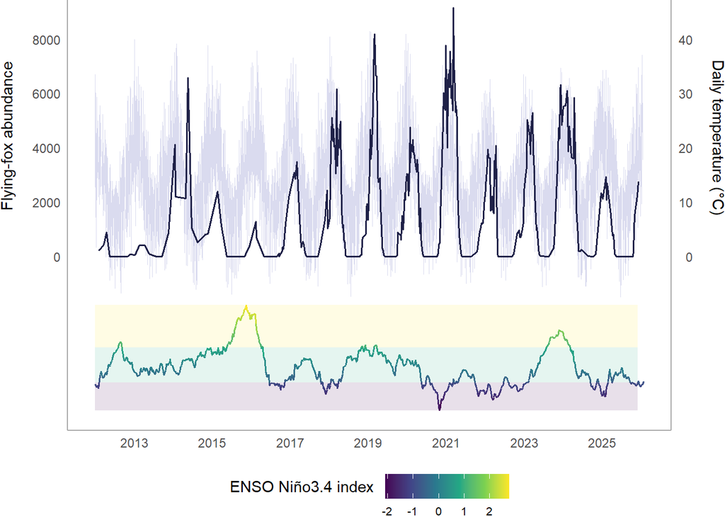

```r
# Draw ribbon and line plot
quiet((survey_weather_plot <- ggplot() +

  # Draw minimum and maximum temperatures as a ribbon
  geom_ribbon(
    data   = weather,
    aes(
      x    = as.Date(date),
      ymin = min * FF_SCALE,
      ymax = max * FF_SCALE),
    alpha  = 0.7,
    fill   = powder) +

  # Draw ENSO Niño3.4 indices line
  geom_line(
    data      = enso,
    aes(
      colour  = nino_3_4,
      x       = as.Date(date),
      y       = (nino_3_4 * 800) -ENSO_ADJ),
    linewidth = 0.6) +

  # Draw rectangle for ENSO upper band
  geom_rect(
    aes(
      xmax      = as.Date(REP_END),
      xmin      = as.Date(ALL_START),
      ymax      = (max(enso$nino_3_4) * 800) - ENSO_ADJ,
      ymin      = (ENSO_NEU           * 800) - ENSO_ADJ),
    alpha       = 0.12,
    fill        = vir1,
    inherit.aes = FALSE) +

  # Draw rectangle for ENSO neutral band
  geom_rect(
    aes(
      xmax      = as.Date(REP_END),
      xmin      = as.Date(ALL_START),
      ymax      = ( ENSO_NEU * 800) - ENSO_ADJ,
      ymin      = (-ENSO_NEU * 800) - ENSO_ADJ),
    alpha       = 0.12,
    fill        = vir7,
    inherit.aes = FALSE) +

  # Draw rectangle for ENSO lower band
  geom_rect(
    aes(
      xmax      = as.Date(REP_END),
      xmin      = as.Date(ALL_START),
      ymax      = (-ENSO_NEU          * 800) - ENSO_ADJ,
      ymin      = (min(enso$nino_3_4) * 800) - ENSO_ADJ),
    alpha       = 0.12,
    fill        = vir14,
    inherit.aes = FALSE) +

  # Draw flying-fox abundance line
  geom_line(
    data      = dat_all,
    aes(
      x       = as.Date(date),
      y       = bats_total),
    colour    = purple,
    linewidth = 0.6) +

  # Configure axes
  scale_colour_viridis_c(name = "ENSO Niño3.4 index") +

  scale_x_date(
    name        = "Year",
    date_labels = "%Y",
    date_breaks = "2 years") +

  scale_y_continuous(
    name     = "Flying-fox abundance",
    breaks   = seq(0, 11000, 2000),
    sec.axis = sec_axis(
      ~ . / FF_SCALE,
      name   = "Daily temperature (°C)",
      breaks = seq(0, 40, 10))) +

  # Configure legend
  guides(
    colour = guide_colourbar(
      title.position = "left",
      title.theme    = element_text(margin = margin(r = 8)),
      title.vjust    = 0.8)) +

  # Apply visual theme
  theme_minimal() +
  theme(
    axis.line          = element_line(colour = mono3),
    axis.text.x        = element_text(vjust  = 1),
    axis.text.y        = element_text(vjust  = 0.5),
    axis.title.x       = element_blank(),
    axis.title.y.left  = element_text(hjust = 0.75, margin = margin(r = 12)),
    axis.title.y.right = element_text(hjust = 0.25, margin = margin(l = 12)),
    legend.position    = "bottom",
    legend.text        = element_text(size   = 8),
    legend.title       = element_text(margin = margin(b = 12)),
    panel.background   = element_rect(colour = NA, fill = "white"),
    panel.border       = element_blank(),
    panel.grid.major   = element_blank(),
    panel.grid.minor   = element_blank(),
    plot.margin        = margin(t = -0.3, r = 0, b = -0.2, l = 0.01, "cm"))))
```

## 4.5 Density maps

Here we map the density of FFs in each tree across the camp. `surveys_wide` is from the `surveys` table in the database, and `trees` is from the `trees` table.

Because we didn’t do any surveys in June and July, but want them to appear in our figure, *we need to add dummy surveys for these months* into the `surveys` dataframe. You can do this by copying the row for Aug 22, 2020 (where all the trees have 0 bats) several times for each missing month per year, and changing the date to one that occurs in each missing month (e.g., Jun 1, 2020 for June).

### 4.5.1 Import

1. Convert tree columns from wide format (one per column) to long format (tree identities listed in one column).

```r
# Read in data
surveys_wide <- read_excel(raw_data, sheet = "surveys") %>%
  subset(SurveyID != "N/A")

# Pivot the table to wide format
surveys <- melt(
  surveys_wide,
  measure.vars  = c(30:203),
  variable.name = "tree",
  value.name    = "bats")
```

2. Merge surveys with coordinates for each tree
3. Create `month` and `year` variables

```r
# Read in the tree-by-tree data
trees <- read_excel(raw_data, sheet = "trees") %>%
  clean_names() %>%
  mutate(tree = tree_id)

# Join survey and tree data
surveys_trees <- left_join(surveys, trees, by = "tree") %>%
  clean_names() %>%
  subset(bats != 999) %>%
  mutate(
    year  = format(date, "%Y"),
    month = format(date, "%b"),
    dates = format(date, "%d %b %y"))
```

4. Get base layer from Google Maps

```r
# Fetch Google basemap
map <- get_map(
  location = c(lon = 149.131749, lat = -35.289492),
  zoom     = 19,
  source   = "google",
  maptype  = "roadmap",
  crop     = FALSE)
```

```r
# Prepare the survey and tree data
data <- surveys_trees %>%

  # Format date column
  mutate(date = as.Date(date, format = c("%d/%m/%Y"))) %>%

  # Select only dates during the current reporting period
  subset(date > REP_START & date < REP_END) %>%

  mutate(
    month = factor(month, levels = c(
      "Dec", "Jan", "Feb",
      "Mar", "Apr", "May",
      "Jun", "Jul", "Aug",
      "Sep", "Oct", "Nov")),

    foxes    = cut(
      as.numeric(bats),
      breaks = c(-Inf, 50, 100, 200, 400, Inf),
      labels = c(
        "0-50",
        "50-100",
        "100-200",
        "200-400",
        ">400"))) %>%

  mutate(foxes = factor(foxes, levels = c(
    ">400",
    "100-200",
    "200-400",
    "50-100",
    "0-50")))
```

### 4.5.2 Plot

6. Map the number of `Bats` recorded per `Month`

```r
# Plot density map
density_map <- ggmap(map) +
  geom_point(
    data,
    mapping = aes(x = longitude, y = latitude),
    alpha   = 0.2,
    col     = "darkgreen",
    shape   = 8,
    size    = 1) +

  geom_point(
    data,
    size    = 1,
    mapping = aes(
      alpha = as.numeric(bats),
      col   = as.numeric(bats),
      x     = longitude,
      y     = latitude)) +

  facet_wrap(~month, ncol = 3) +

  guides(
    alpha     = guide_legend(
      title   = "Number of \nflying-foxes\nrecorded",
      reverse = TRUE),
    col       = guide_legend(
      title   = "Number of \nflying-foxes\nrecorded",
      reverse = TRUE)) +

  labs(x = "", y = "") +

  scale_colour_gradient2(
    low      = 0,
    midpoint = 10,
    mid      = "yellow",
    high     = "red") +

  # Apply visual theme
  theme(
    axis.line        = element_line(colour = mono3),
    axis.text.x      = element_blank(),
    axis.text.y      = element_blank(),
    axis.ticks.x     = element_blank(),
    axis.ticks.y     = element_blank(),
    axis.title.x     = element_text(vjust = -2),
    axis.title.y     = element_text(vjust = 5, margin = margin(r = 5)),
    legend.key       = element_blank(),
    legend.text      = element_text(size = 8),
    legend.title     = element_text(size = 10),
    panel.grid       = element_blank(),
    panel.background = element_rect(fill = "white", colour = NA),
    plot.margin      = margin(t = -10, r = 4, b = 5, l = 5),
    strip.background = element_rect(fill   = purple),
    strip.text       = element_text(colour = "white"))

# Display map
# print(density_map)
```

## 4.6 Seasonal migration

Here we plot the dates that flying-foxes occupied the camp each year. Because the flying-foxes never vacated the camp in 2014, we entered back-to-back dates to enable plotting.

### 4.6.1 Import

```r
# Read in dates of camp occupation
occ <- read_excel(raw_data, sheet = "occupation") %>%
  clean_names() %>%

  # Exclude years with missing dates
  filter(!is.na(arrival) & !is.na(departure)) %>%
  mutate(across(c(
    peak_date,
    departure,
    arrival,
    year_start,
    year_end),
  as.Date),

  # Extract month and day and apply a single year
  arr_date  = as.Date(paste("2012", format(arrival,   "%m-%d"), sep = "-")),
  dep_date  = as.Date(paste("2012", format(departure, "%m-%d"), sep = "-")),
  peak_date = as.Date(paste("2012", format(peak_date, "%m-%d"), sep = "-")),

  # Treat year as a factor
  year = factor(year),

  # Make another year factor for a secondary y-axis
  year_sec = as.numeric(as.character(year)))
```

### 4.6.2 Plot

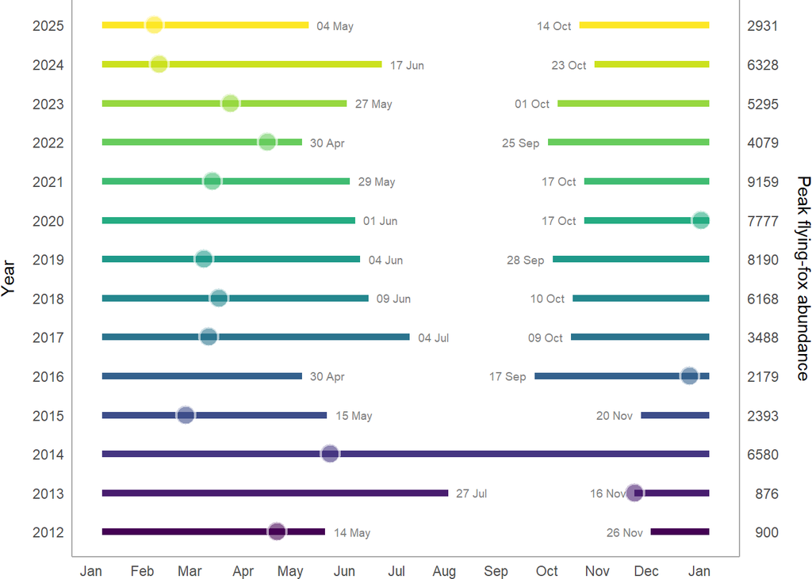

```r
# Generate plot
(occ_plot <- ggplot(occ) +
  geom_segment(
    aes(
      color   = year,
      y       = year_sec,
      yend    = year_sec,
      x       = as.Date(format(year_start, "2012-%m-%d")),
      xend    = as.Date(format(  dep_date, "2012-%m-%d"))),
    linewidth = 2) +

  geom_segment(
    aes(
    color     = year,
    x         = as.Date(format(arr_date, "2012-%m-%d")),
    xend      = as.Date(format(year_end, "2012-%m-%d")),
    y         = year_sec, yend = year_sec),
    linewidth = 2) +

  geom_point(
    aes(
      fill = year,
      x = as.Date(format(peak_date, "2012-%m-%d")),
      y = year_sec),
    alpha  = 0.6,
    color  = "white",
    shape  = 21,
    size   = 5,
    stroke = 1.2) +

   # Add departure date labels after the bar
  geom_text(
    aes(
      label = format(dep_date, "%d %b"),
      x     = as.Date(format(dep_date, "2012-%m-%d")) + 5,
      y     = year_sec),
    color   = "grey50",
    hjust   = 0,
    size    = 2.5) +

   # Add arrival date labels before the bar
  geom_text(
    aes(
      label = format(arr_date, "%d %b"),
      x     = as.Date(format(arr_date, "2012-%m-%d")) - 5,
      y     = year_sec),
    color   = "grey50",
    hjust   = 1,
    size    = 2.5) +

   scale_x_date(
     date_labels = "%b",
     date_breaks = "1 month",
     limits      = c(
       as.Date("2012-01-01"),
       as.Date("2012-12-31"))) +

  labs(x = "Month") +
  scale_color_viridis_d() +
  scale_fill_viridis_d() +
  scale_y_continuous(
    name     = "Year",
    breaks   = occ$year_sec,
    labels   = occ$year,
    sec.axis = sec_axis(
      ~.,
      breaks = occ$year_sec,
      labels = occ$peak_abundance,
      name   = "Peak flying-fox abundance")) +

  # Apply visual theme
  theme_minimal() +
  theme(
    axis.line          = element_line(colour = mono3),
    axis.text.x        = element_text(hjust = 1),
    axis.text.y        = element_text(hjust = 1),
    axis.title.x       = element_blank(),
    axis.title.y       = element_text(margin = margin(r = 10)),
    axis.title.y.right = element_text(margin = margin(l = 10)),
    legend.position    = "none",
    legend.text        = element_text(size = 8),
    legend.title       = element_blank(),
    panel.background   = element_rect(fill = "white", colour = NA),
    panel.grid         = element_blank(),
    plot.margin        = margin(t = 0, r = 0, b = 0, l = 0)))
```

## 4.7 Categorical variables

### 4.7.1 Import

```r
# Prepare levels counts for categorical variables
dat_cat <- dat_cur %>%

  # Remove estimates
  filter(survey == "Count") %>%

  # Rename categorical variables
  rename(
    heat  = heat_stress,
    humid = humidity,
    pups  = mothers_and_pups) %>%

  # Format month
  mutate(month = floor_date(date, "month")) %>%

  # Transform to long format
  pivot_longer(
    cols      = all_of(cat_vars),
    names_to  = "var",
    values_to = "level") %>%

  # Remove NAs
  filter(!is.na(level), level != "") %>%

  # Sum levels per variable
  count(month, var, level)
```

### 4.7.2 Plot

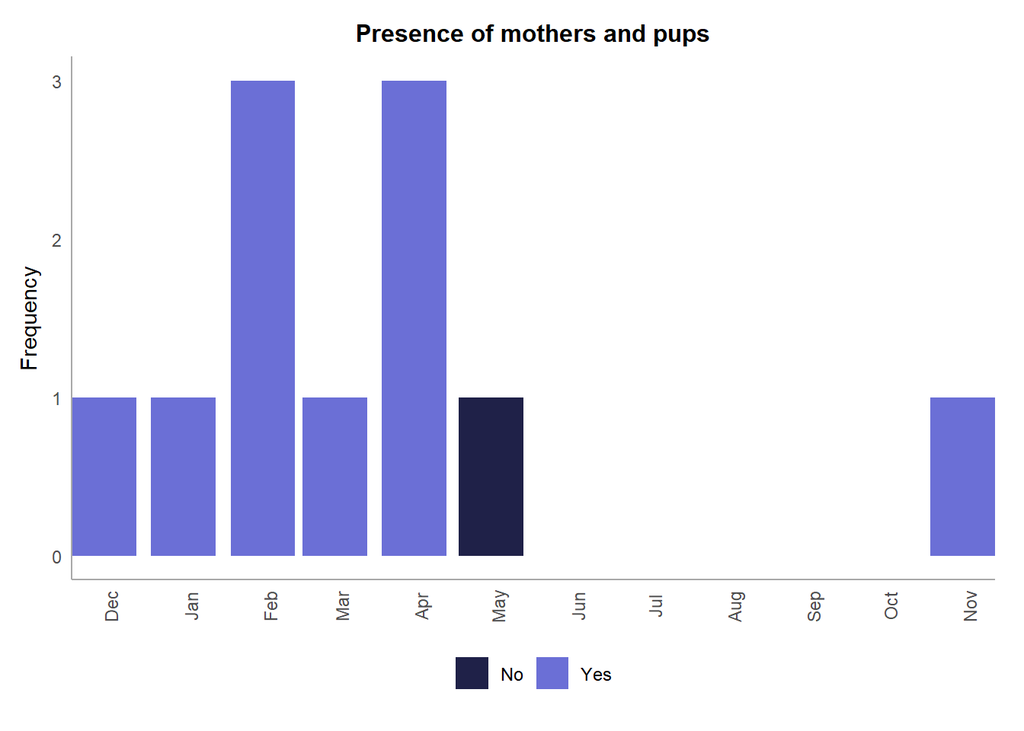

```r
# Barplot categorical variables
cat_plots <- dat_cat %>%

  # Group by categorical variable
  split(.$var) %>%
    purrr::map(~ {
      v <- unique(.x$var)

    ggplot(.x, aes(x = month, y = n, fill = level)) +

      # Draw bar plot
      geom_col() +

      # Define labels
      labs(
        fill  = "",
        title = cat_labs[[v]],
        x     = "Month",
        y     = "Frequency") +

      # Define fill colours
      scale_fill_manual(
        values = c(purple, lilac, lime, tan)) +

      # Define date axis
      scale_x_date(
        date_labels = "%b",
        date_breaks = "1 month",
        expand      = c(0, 0)) +

      # Apply visual theme
      theme_minimal() +
      theme(
        axis.line        = element_line(colour = mono3),
        axis.text.x      = element_text(angle  = 90, vjust = 1),
        axis.text.y      = element_text(vjust  = 0.5),
        axis.title.x     = element_blank(),
        axis.title.y     = element_text(vjust  = 3, margin = margin(r = 1)),
        legend.position  = "bottom",
        legend.text      = element_text(size   = 9),
        legend.title     = element_blank(),
        panel.background = element_rect(colour = NA, fill = "white"),
        panel.grid.major = element_blank(),
        panel.grid.minor = element_blank(),
        panel.border     = element_blank(),
        plot.margin      = margin(t = 0.4, r = 0.5, b = 0.5, l = 0.5, "cm"),
        plot.title       = element_text(
          face = "bold", hjust = 0.5, size = 12))})

# Display plots
print(cat_plots$pups)
```

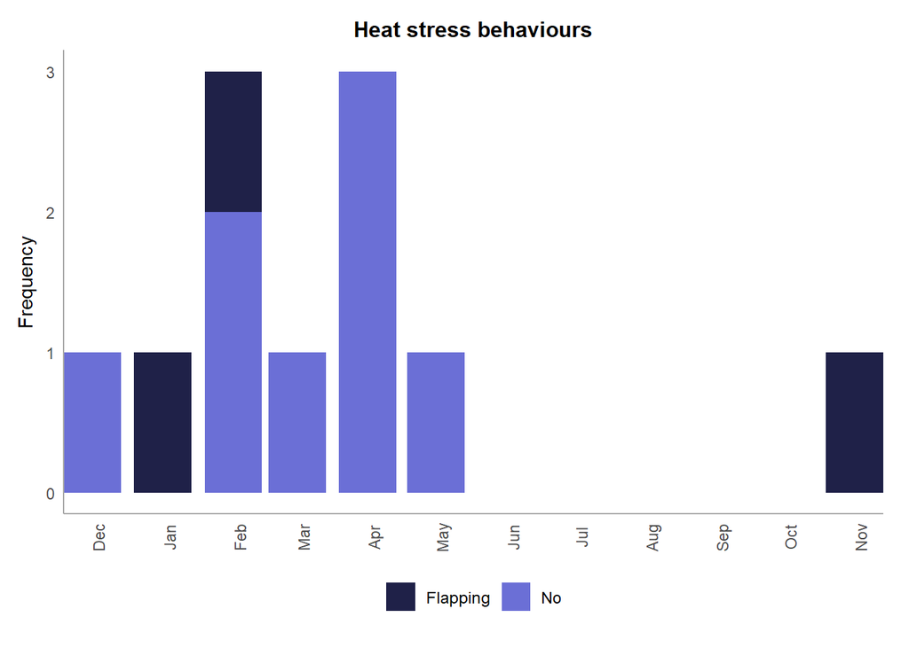

```r
print(cat_plots$heat)
```

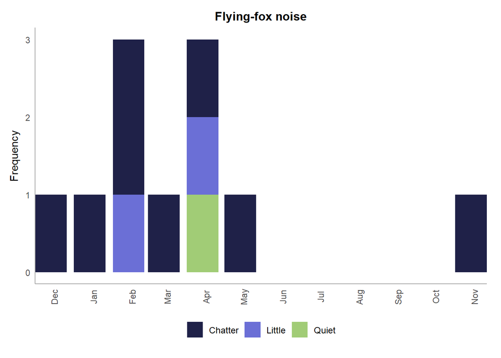

```r
print(cat_plots$bat_noise)
```

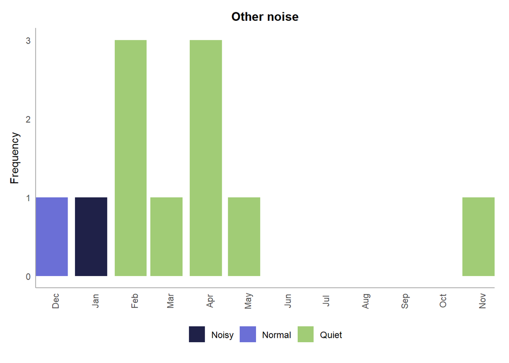

```r
print(cat_plots$other_noise)
```

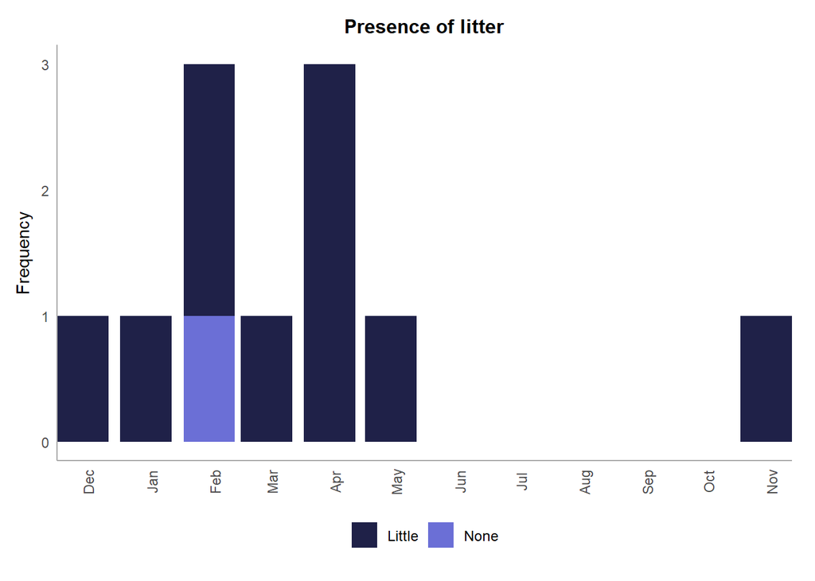

```r
print(cat_plots$rubbish)
```

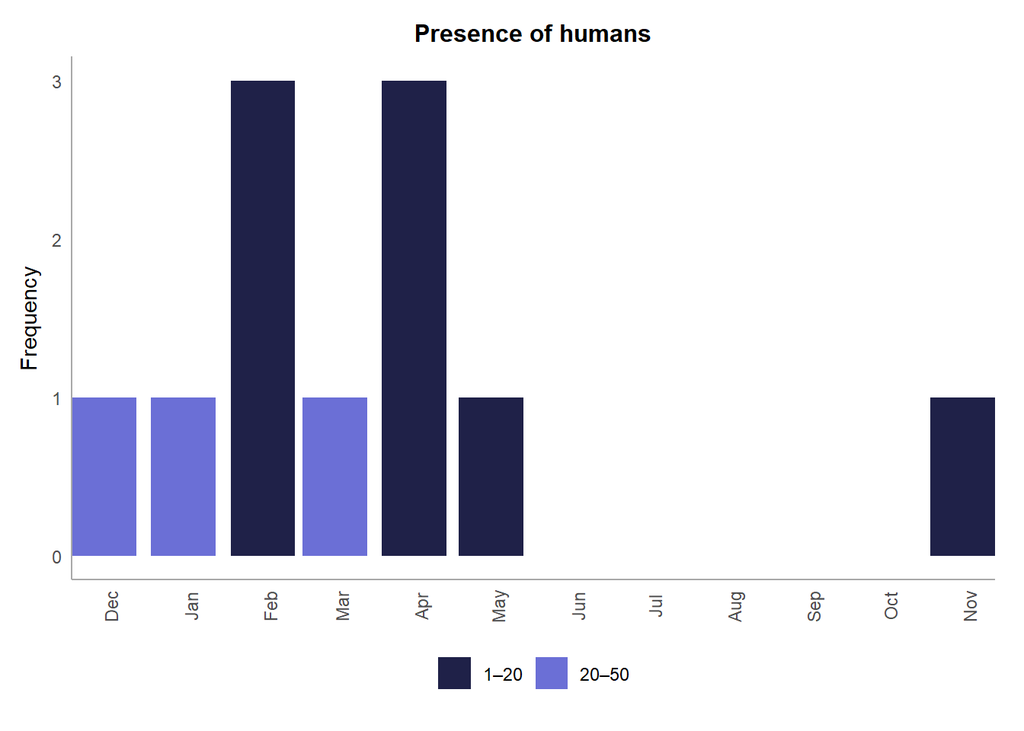

```r
print(cat_plots$humans)
```

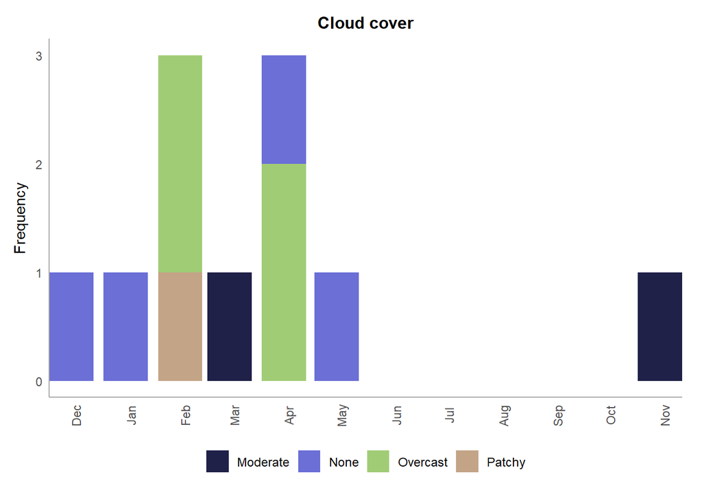

```r
print(cat_plots$cloud)
```

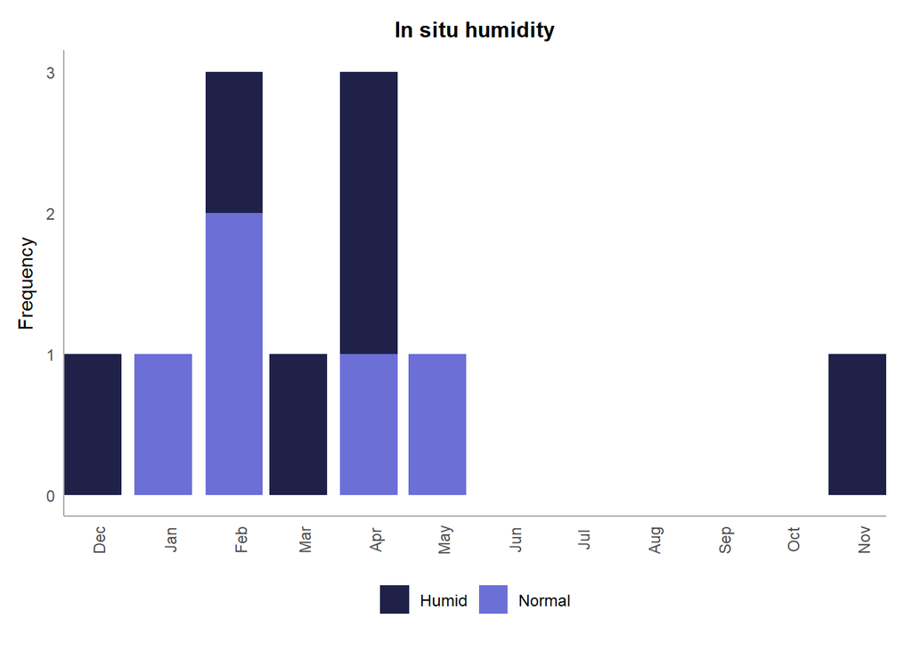

```r
print(cat_plots$humid)
```

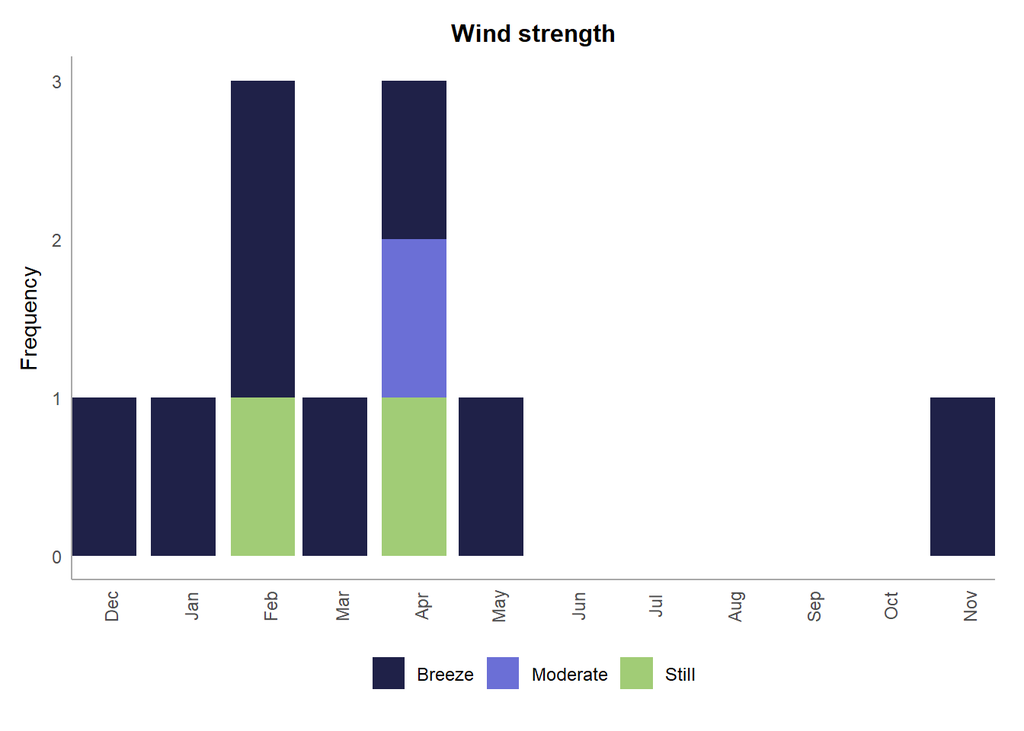

```r
print(cat_plots$wind)
```

## 4.8 Canopy cover

Since 2019, we estimated the range (minimum and maximum) proportion of canopy cover for the four main tree types at the Commonweath Park FF camp:

- **Broadleaves:** (e.g., elm *Ulmus* spp., oak *Quercus* spp., poplar *Populus* spp., and silver birch *Betula pendula*),
- **Needleleaves:** (e.g., cedar *Cedrus* spp., cypress *Cupressus* spp., sequoia *Sequoiadendron* spp.),
- **Eucalypts:** (e.g., Blakely’s red gum *Eucalyptus blakelyi*, mealy bundy *Eucalyptus nortonii*, river peppermint *Eucalyptus elata*), and
- **Laurels:** Camphor laurel (*Cinnamomum camphora*)

### 4.8.1 Import

```r
# Prepare flying-fox abundance data
dat_ff <- dat %>%
  mutate(ff = as.numeric(ghff) + as.numeric(lrff)) %>%
  select(date, ff)
# Prepare minimum and maximum temperature data
weather_can <- weather %>%
  mutate(
    date      = as.Date(date),
    max_temp  = as.numeric(max),
    min_temp  = as.numeric(min),
    mean_temp = (as.numeric(min) + as.numeric(max)) / 2) %>%
  select(date, max_temp, min_temp, mean_temp)

# Prepare canopy cover measures
canopy <- read_excel(raw_data, sheet = "surveys", na = c("N/A")) %>%

  # Standardise column names
  clean_names() %>%

  # Convert date
  mutate(date = as.Date(date, format = c("%d/%m/%Y")),
         year = lubridate::year(date)) %>%

  # Select canopy cover columns
  select(
    date,
    year,
    ends_with("_canopy_min"),
    ends_with("_canopy_max")) %>%

  # Pivot tree species columns to long format
  pivot_longer(
    cols      = -c(date, year),
    names_to  = c("species", "stat"),
    names_sep = "_canopy_",
    values_to = "canopy") %>%

  # Parse only numeric canopy cover values
  mutate(canopy = readr::parse_number(as.character(canopy))) %>%

  # Pivot min and max columns to long format
  pivot_wider(
    names_from  = stat,
    values_from = canopy,
    values_fn   = mean,
    values_fill = NA_real_) %>%

  # Reorder tree species levels
  mutate(species = factor(
    species,
    levels = c("oak",         "pine",         "euc",       "laurel"),
    labels = c("Broadleaves", "Needleleaves", "Eucalypts", "Laurels"))) %>%

  # Generate mean cover, season, and reporting period columns
  mutate(

    cover  = (min + max) / 2,

    season = as.factor(case_when(
      month(date) %in% c(12, 1, 2)  ~ "Summer",
      month(date) %in% c(3, 4, 5)   ~ "Autumn",
      month(date) %in% c(6, 7, 8)   ~ "Winter",
      month(date) %in% c(9, 10, 11) ~ "Spring")),

    period = case_when(
      date >= as.Date(REP_START)  & date <= as.Date(REP_END) ~ "Reporting",
      date >= TREE_START          & date <= TREE_END         ~ "Baseline",
      TRUE ~ NA_character_)) %>%

  mutate(season = factor(season, levels = c(
    "Summer", "Autumn", "Winter", "Spring"))) %>%

  # Remove surveys before they became standardised
  filter(!is.na(period)) %>%

  # Join flying-fox abundances to canopy cover df
  left_join(dat_ff, by = "date") %>%

  # Join temperature
  left_join(weather_can, by = "date")

# Export df to a new sheet in the running workbook
workbook <- export_sheet(canopy, sheet = "canopy")
```

### 4.8.2 Statistics

```r
# Print statistics for canopy cover estimates
nrow(canopy)
```

```
## [1] 660
```

```r
min(canopy$date, na.rm = TRUE) # 2018-12-15
```

```
## [1] "2018-12-15 UTC"
```

```r
max(canopy$date, na.rm = TRUE) # 2024-09-29
```

```
## [1] "2024-09-29 UTC"
```

```r
# Calculate baseline means
(baseline_means <- canopy %>%
  filter(period == "Baseline") %>%
  group_by(species, season) %>%
  summarise(
    n_surveys  = n(),
    mean_cover = mean(cover, na.rm = TRUE),

    min_cover  = min(cover, na.rm = TRUE),
    min_dates  = paste(sort(unique(date[cover == min_cover])),
                        collapse = ", "),

    max_cover  = max(cover, na.rm = TRUE),
    max_dates  = paste(sort(unique(date[cover == max_cover])),
                       collapse = ", "),
    .groups    = "drop") %>%
  arrange(species, season))
```

```
## # A tibble: 16 × 8
##    species   season n_surveys mean_cover min_cover min_dates max_cover max_dates
##    <fct>     <fct>      <int>      <dbl>     <dbl> <chr>         <dbl> <chr>
##  1 Broadlea… Summer        65      67.3       35   2020-02-…        90 2019-01-…
##  2 Broadlea… Autumn        61      44.1        2.5 2020-05-…        90 2022-03-…
##  3 Broadlea… Winter         4       5.83       0   2023-08-…        15 2024-06-…
##  4 Broadlea… Spring        35      52.6        2.5 2022-09-…        95 2020-10-…
##  5 Needlele… Summer        65      48.0        0   2023-12-…        90 2021-02-…
##  6 Needlele… Autumn        61      50.7       10   2020-03-…        90 2022-03-…
##  7 Needlele… Winter         4      56.7       40   2020-08-…        70 2023-08-…
##  8 Needlele… Spring        35      57.3        0   2020-10-…        90 2022-10-…
##  9 Eucalypts Summer        65      28.3       10   2022-01-…        70 2021-01-…
## 10 Eucalypts Autumn        61      28.9       10   2019-03-…        75 2023-04-…
## 11 Eucalypts Winter         4      27.5        2.5 2020-08-…        70 2024-06-…
## 12 Eucalypts Spring        35      31.1       10   2019-09-…        70 2021-11-…
## 13 Laurels   Summer        65      70.9       40   2021-01-…        95 2019-01-…
## 14 Laurels   Autumn        61      66.7       20   2022-04-…        95 2021-05-…
## 15 Laurels   Winter         4      56.7       30   2020-08-…        80 2023-08-…
## 16 Laurels   Spring        35      69.2       10   2020-10-…        98 2020-11-…
```

> 🚩 *Draft until tree-by-tree data for 2025 reporting period is available*.

```r
# Calculate seasonal reporting-period statistics
(seasonal_reporting <- canopy %>%
  filter(period == "Reporting") %>%
  group_by(species, season) %>%

  summarise(
    mean_cover = mean(cover, na.rm = TRUE),
    min_cover  = min( cover, na.rm = TRUE),
    max_cover  = max( cover, na.rm = TRUE),
    n_surveys  = n(),
    .groups = "drop") %>%

  left_join(baseline_means, by = "species") %>%

  mutate(
    diff_abs = mean_cover - baseline_mean,
    diff_pct = 100 * diff_abs / baseline_mean) %>%

  arrange(species, season))
```

Here we fit per-species GLMs for canopy cover by flying-fox abundance, mean temperature, season, and year.

```r
# Prepare canopy cover modelling data
canopy_mod <- canopy %>%
  filter(period == "Baseline") %>%
  mutate(
    date      = as.Date(date),
    year      = factor(year),
    season    = factor(season, levels = c(
      "Summer", "Autumn", "Winter", "Spring")),
    mean_temp = as.numeric(mean_temp),
    ff        = as.numeric(ff)) %>%
  drop_na(cover, ff, mean_temp, season, year) %>%
  droplevels()

# Fit GLM for canopy cover per species
glm_results <- canopy_mod %>%
  group_by(species) %>%
  nest() %>%

  mutate(
    model = map(
      data,
      ~ glm(
        cover ~ ff + mean_temp + season + year,
        data = .x,
        family = gaussian())),
    tidy = map(model, broom::tidy)) %>%

  select(species, tidy) %>%
  unnest(tidy) %>%
  filter(term != "(Intercept)") %>%

  transmute(
    species,
    fixed_effect = case_when(
      term == "ff"                 ~ "Flying-fox abundance",
      term == "mean_temp"          ~ "Mean temperature",
      grepl("^season", term)       ~ "Season",
      grepl("^year", term)         ~ "Year",
      TRUE ~ term),
    p_value = p.value) %>%
  arrange(species, fixed_effect) %>%

  print(n = nrow(.))
```

```
## # A tibble: 44 × 3
## # Groups:   species [4]
##    species      fixed_effect         p_value
##    <fct>        <chr>                  <dbl>
##  1 Broadleaves  Flying-fox abundance 0.219
##  2 Broadleaves  Mean temperature     0.0150
##  3 Broadleaves  Season               0.00542
##  4 Broadleaves  Season               0.00548
##  5 Broadleaves  Season               0.398
##  6 Broadleaves  Year                 0.172
##  7 Broadleaves  Year                 0.232
##  8 Broadleaves  Year                 0.378
##  9 Broadleaves  Year                 0.384
## 10 Broadleaves  Year                 0.471
## 11 Broadleaves  Year                 0.153
```

[output cut: 33 more lines]

### 4.8.3 Smooth values

```r
# Define axis mapping
FF_MAX     <- 9000
CANOPY_MAX <- 100
FF_PER_PC  <- FF_MAX / CANOPY_MAX

# Smooth canopy min/max within species
canopy_sm <- canopy %>%
  group_by(species) %>%
  mutate(

    # Calculate mean canopy cover
    mean_cc = (min + max) / 2,

    # Calculate smoothed mean canopy cover
    mean_sm = {
      fit <- loess(
        mean_cc   ~ as.numeric(date),
        data      = pick(date, mean_cc),
        na.action = na.exclude,
        span      = 0.3)
      predict(fit, newdata = data.frame(date = as.numeric(date)))},

    # Calculate smoothed min canopy cover
    min_sm = {
      fit <- loess(
        min       ~ as.numeric(date),
        data      = pick(date, min),
        na.action = na.exclude,
        span      = 0.3)
      predict(fit, newdata = data.frame(date = as.numeric(date)))},

    #Calculate smoothed max canopy cover
    max_sm = {
      fit <- loess(
        max       ~ as.numeric(date),
        data      = pick(date, max),
        na.action = na.exclude,
        span      = 0.3)
      predict(fit, newdata = data.frame(date = as.numeric(date)))}) %>%

  ungroup()
```

### 4.8.4 Plot

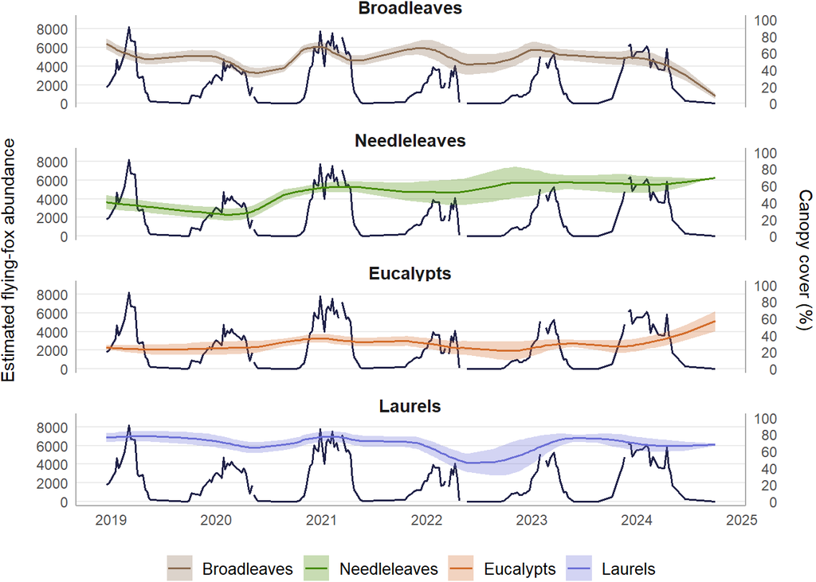

```r
# Define margin() namespace
margin <- ggplot2::margin

# Plot and display ribbon for canopy cover
(canopy_plot <- ggplot(
  canopy_sm,
  aes(
    group = species,
    x     = date)) +

  # Split plot by tree species
  facet_wrap(~ species, ncol = 1) +

  # Draw flying-fox abundance line (primary axis)
  geom_line(
    aes(y       = ff),
    colour      = purple,
    linewidth   = 0.7,
    show.legend = FALSE) +

  # Draw canopy cover line
  geom_line(
    aes(
      colour  = species,
      y       = mean_sm * FF_PER_PC),
    linewidth = 0.7) +

  # Draw smoothed canopy cover ribbon, scaled onto FF axis
  geom_ribbon(
    aes(
      fill = species,
      ymin = min_sm * FF_PER_PC,
      ymax = max_sm * FF_PER_PC),
    alpha = 0.3) +

  # Configure axes
  scale_colour_manual(
  values = c(
    "Broadleaves"  = brown,
    "Needleleaves" = green,
    "Eucalypts"    = orange,
    "Laurels"      = lilac)) +

  scale_fill_manual(
  values = c(
    "Broadleaves"  = brown,
    "Needleleaves" = green,
    "Eucalypts"    = orange,
    "Laurels"      = lilac)) +

  # Configure x-axis
  scale_x_date(
    date_breaks = "1 year",
    date_labels = "%Y") +

  # Configure primary y-axis
  scale_y_continuous(
    limits   = c(0, FF_MAX),
    breaks   = seq(0, FF_MAX, 2000),
    name     = "Estimated flying-fox abundance",

    # Configure secondary y-axis
    sec.axis = sec_axis(
      ~ . / FF_PER_PC,
      name   = "Canopy cover (%)",
      breaks = seq(0, 100, 20))) +

  # Apply visual theme
  theme_minimal() +
  theme(
    axis.line          = element_line(colour = mono3),
    axis.text.x        = element_text(vjust  = 1),
    axis.text.y        = element_text(vjust  = 0.5),
    axis.title.x       = element_blank(),
    axis.title.y.left  = element_text(margin = ggplot2::margin(r = 12)),
    axis.title.y.right = element_text(margin = ggplot2::margin(l = 12)),
    legend.position    = "bottom",
    legend.text        = element_text(size   = 10),
    legend.title       = element_blank(),
    panel.background   = element_rect(colour = NA, fill = "white"),
    panel.border       = element_blank(),
    panel.grid.minor.x = element_blank(),
    panel.grid.major.x = element_blank(),
    panel.grid.minor.y = element_blank(),
    plot.margin        = margin(t = -0.35, r = 0.05, b = -0.2, l = 0.01, "cm"),
    strip.text         = element_text(
      face = "bold", margin = margin(t = 9), size = 11)))
```